# Examples of FFTs

Nathaniel Phillips

2016-08-16

# Examples

Here are some examples of FFTs created from datasets in the `FFTrees` package

## Mushrooms

The `mushrooms` dataset contains data about mushrooms (see `?mushrooms` for details). The goal of our model is to predict which mushrooms are poisonous based on 22 cues ranging from the mushroom’s odor, color, etc.

Let’s create some ffts. We’ll separate the data into a 50% training and a 50% testing dataset with the `train.p = .5` argument:

```r
set.seed(100) # For replicability of the training / test data split

mushrooms.fft <- fft(formula = poisonous ~.,
                     data = mushrooms,
                     train.p = .5)
```

Here’s basic information about the trees:

```r
mushrooms.fft
```

```
## [1] "An fft object containing 6 trees using 4 cues {odor,sporepc,gcolor,ringtype} out of an original 22"
## [1] "Data were trained on 4062 exemplars, and tested on 4062 new exemplars"
## [1] "FFT AUC: (Train = 0.99, Test = 0.99)"
## [1] "My favorite tree is #2 [Training: HR = 0.86, FAR = 0], [Testing: HR = 0.85, FAR = 0]"
```

[Cool beans.](https://goo.gl/B7YDuC)

### mushrooms cue accuracies

First, let’s look at the individual cue training accuracies with `showcues`:

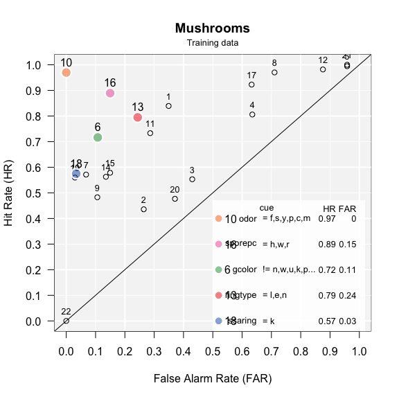

```r
showcues(mushrooms.fft, main = "Mushrooms")
```

It looks like the cues *oder* and *sporepc* are the best predictors. in fact, the single cue *odor* has a hit rate of 97% and a false alarm rate of 0%! Based on this, we should expect the final FFT to have no more than these two cues:

### mushrooms FFT

Now let’s plot the best tree applied to the test dataset

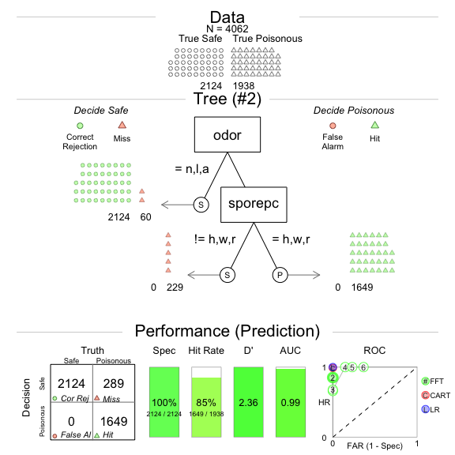

```r
plot(mushrooms.fft,
     data = "test",
     description = "Mushrooms FFT",
     decision.names = c("Safe", "Poisonous")
     )
```

Now, let’s say that you talk to a mushroom expert who says that we are using the wrong cues. According to her, the best predictors for poisonous mushrooms are *ringtype* and *ringnum*. Let’s build a set of trees with these cues and see how they perform relative to our initial tree:

```r
set.seed(100) # for replicability
mushrooms.ring.fft <- fft(formula = poisonous ~ ringtype + ringnum,
                          data = mushrooms,
                          train.p = .5
                          )
```

Here is the final tree:

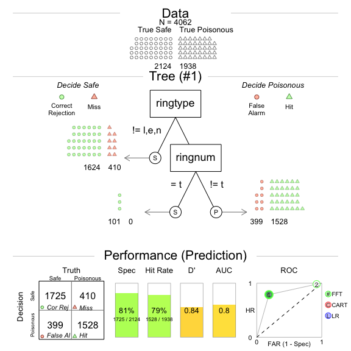

```r
plot(mushrooms.ring.fft,
     data = "test",
     description = "Mushrooms (Ring only) FFT",
     decision.names = c("Safe", "Poisonous")
     )
```

As we can see, this tree did not perform nearly as well as our earlier one. The new d-prime is only 0.84.

## Iris

The `iris` dataset contains data about 150 flowers (see `?iris`). Our goal is to predict which flowers are of the class Virginica

```r
iris.fft <- fft(
  formula = virginica ~.,
  data = iris,
  train.p = .5
  )
```

### iris cue accuracies

First, let’s look at the individual cue training accuracies with `showcues`:

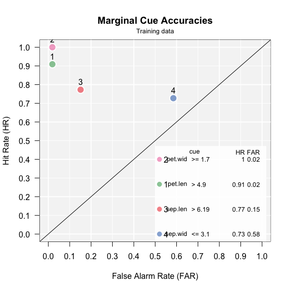

```r
showcues(iris.fft)
```

It looks like the cues *pet.wid* and *pet.len* are the best predictors. Based on this, we should expect the final FFT will likely use just one or both of these cues

### iris FFT

Now let’s plot the best tree applied to the test dataset

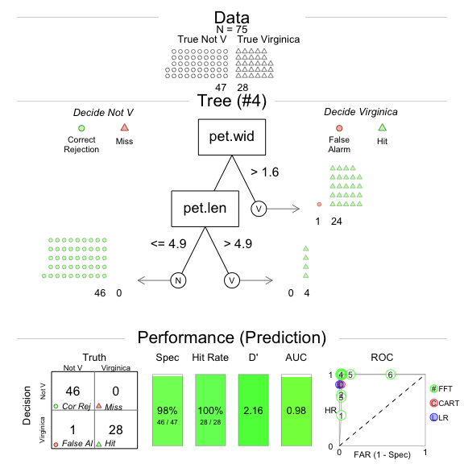

```r
plot(iris.fft,
     data = "test",
     description = "Iris FFT",
     decision.names = c("Not V", "Virginica")
     )
```

Now, this tree did quite well, but what if someone wants a tree with the maximum possible hit-rate. If we look at the ROC plot in the bottom right corder of the plot above, we can see that tree #6 has a hit-rate of 100%. Let’s look at that tree:

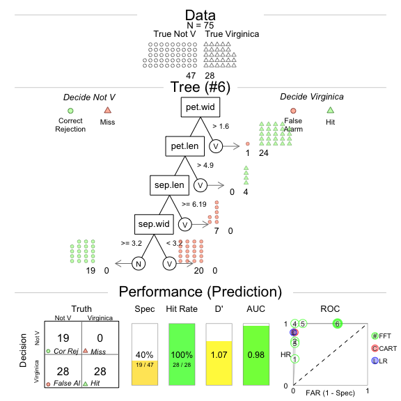

```r
plot(iris.fft,
     data = "test",
     description = "Iris FFT",
     decision.names = c("Not V", "Virginica"),
     which.tree = 6     # Show tree #6
     )
```

As you can see, this tree does indeed have a maximum hit-rate. However, it comes at a high cost to specificity.